# Nonlinear time-series analysis (NTSA) with `ntsa` + `dynamodels`

Given a single long trajectory of a dynamical system — a pressure probe in a combustor, one component of a chaotic attractor — how do we decide *what kind* of dynamics we are looking at: fixed point, limit cycle, quasiperiodic, frequency-locked, or chaotic? This tutorial walks through the `ntsa` package, which packages the classical toolbox of nonlinear time-series analysis (Kantz & Schreiber, 2004) for **any** `dynamodels`-style model. The package has three modules (models come from [`dynamodels`](https://github.com/andreanovoa/dynamodels)):

[output not shown]

**Why a data-assimilation group cares.** Thermoacoustic systems (Rijke tube, annular combustor, azimuthal instabilities) bifurcate from steady operation to limit-cycle, quasiperiodic, frequency-locked and chaotic oscillations as operating conditions vary. Before we assimilate data or train a reduced-order model, we must *characterize the regime* — and the evidence we present for each regime call is exactly the 5-panel diagnostic row of our paper supplement: **time series (+ zoom inset) | power spectral density | 3-D delay portrait | first-return map | recurrence plot**, backed by Lyapunov exponents. `characterize()` reproduces that figure for any model in one call (Section 9).

Throughout we use the Lorenz systems as testbeds, because they are cheap and every number has a known reference value: for Lorenz-63 at $\rho = 28$ the Lyapunov spectrum is $(0.906,\ 0,\ -14.57)$, and for Lorenz-96 at $F = 8$, $N_x = 10$ the leading exponent is $\lambda_1 \approx 1.2$ with three positive exponents. Every stochastic step is seeded, so the notebook self-checks with `assert`s on re-runs.

```python
# ruff: noqa: E402, I001  (the env pinning below must run before numpy is imported)
import os
# Pin the BLAS thread pools BEFORE importing numpy. Everything in this module is small or
# serial linear algebra (3x3 QR steps, one 2000x2000 eigendecomposition); on a busy
# many-core machine, letting OpenBLAS spawn one thread per core makes np.linalg.eigh
# 10-40x SLOWER through contention. One thread is the fast setting here.
for var in ('OMP_NUM_THREADS', 'OPENBLAS_NUM_THREADS', 'MKL_NUM_THREADS'):
    os.environ.setdefault(var, '1')

%matplotlib inline
import numpy as np
import matplotlib.pyplot as plt
from IPython.display import Image

from ntsa import tools as ntsa_tools
from ntsa import lyapunov as lyap
from ntsa import characterize as chz

from dynamodels.physical import Lorenz63, Lorenz96

l63 = Lorenz63(rho=28., dt=0.01)
print(f"{type(l63).__name__}: rho={l63.rho}, sigma={l63.sigma}, beta={l63.beta:.4g}, dt={l63.dt}")
print(f"t_lyap = {l63.t_lyap:.4f}  (1/0.9056),  t_CR = {l63.t_CR:.4f},  t_transient = {l63.t_transient:.4f}")
print(f"Nphi = {l63.Nphi}, Nq = {l63.Nq}, obs_labels = {l63.obs_labels}")
```

```
Lorenz63: rho=28.0, sigma=10.0, beta=2.667, dt=0.01
t_lyap = 1.0905  (1/0.9056),  t_CR = 4.4170,  t_transient = 11.0424
Nphi = 3, Nq = 3, obs_labels = ['$x$', '$y$', '$z$']
```

The model carries its own time scales: the **Lyapunov time** $t_\mathrm{lyap} = 1/\lambda_1 = 1/0.9056$ (the e-folding time of infinitesimal errors — the natural unit for "how long is long"), a characteristic recurrence time `t_CR`, and the transient `t_transient` to discard before the trajectory settles on the attractor.

## 2. Generating clean long trajectories

Two idioms are used everywhere in this module.

**`respawn(model, psi0=None, dt=None, **overrides)`** — `dynamodels` models freeze their parameters at construction (`alpha0`) and accumulate history as they are integrated, so the clean way to change a parameter — or simply to get a pristine copy with an empty history — is to build a *fresh instance*. `respawn` reads `type(model)`, carries over `alpha0`, the `fixed_params` (e.g. `Nx` for Lorenz-96) **and** the observation configuration (`observe_dims`/`observed_idx`), then applies your overrides on top.

**`run_long(model, t_run, t_transient=None)`** — the transient-discard idiom: integrate for `t_transient` (default `model.t_transient`), reset the history clock to $t = 0$, then record `t_run` time units. It returns `(t, y, psi)` with shapes `(Nt,)`, `(Nt, Nq)` and `(Nt, Nphi)`: the time stamps, the *observable* history and the *full-state* history of ensemble member 0 (everything in this module is strictly serial, $m = 1$). Note that `run_long` mutates and closes the model — always feed it a respawned copy.

```python
l63b = ntsa_tools.respawn(l63, rho=30.)   # the override wins; everything else is carried over
print(f"respawned copy: rho={l63b.rho} (overridden), sigma={l63b.sigma}, "
      f"beta={l63b.beta:.4g}, dt={l63b.dt}, observe_dims={l63b.observe_dims}")
l63b.close()

t, y, psi = ntsa_tools.run_long(ntsa_tools.respawn(l63), t_run=60 * l63.t_lyap)
dt = float(t[1] - t[0])
x = y[:, 0]
print(f"t: {t.shape},  y: {y.shape} = (Nt, Nq),  psi: {psi.shape} = (Nt, Nphi),  dt = {dt:.3g}")
```

```
respawned copy: rho=30.0 (overridden), sigma=10.0, beta=2.667, dt=0.01, observe_dims=[0, 1, 2]
t: (6544,),  y: (6544, 3) = (Nt, Nq),  psi: (6544, 3) = (Nt, Nphi),  dt = 0.01
```

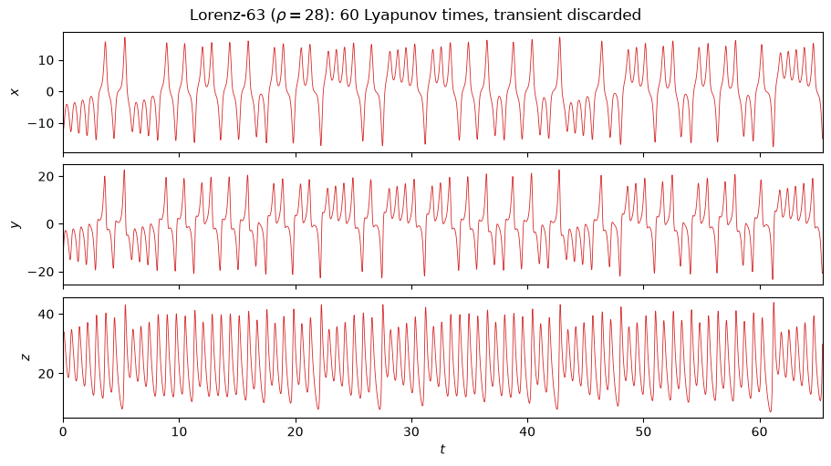

```python
fig, axs = plt.subplots(3, 1, figsize=(9, 5), sharex=True, layout='constrained')
for iq, ax in enumerate(axs):
    ax.plot(t, y[:, iq], lw=0.6, color='tab:red')
    ax.set_ylabel(l63.obs_labels[iq])
    ax.margins(x=0)
axs[-1].set_xlabel('$t$')
fig.suptitle(r'Lorenz-63 ($\rho = 28$): 60 Lyapunov times, transient discarded');
```

## 3. Signal statistics

`signal_stats(x, dt)` bundles the standard first look at a scalar signal into one dict: the first four moments (mean, standard deviation, skewness, kurtosis), the probability density function (histogram), the power spectral density (reusing `ntsa.tools.fun_PSD`, the same PSD routine used across the repo), and the normalized autocorrelation function.

```
{'mean': 0.332, 'std': 7.891, 'skew': -0.082, 'kurtosis': -0.577}
```

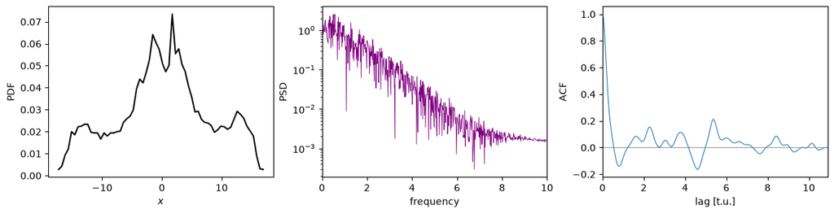

```python
stats = ntsa_tools.signal_stats(x, dt)
print({k: round(stats[k], 3) for k in ('mean', 'std', 'skew', 'kurtosis')})

fig, axs = plt.subplots(1, 3, figsize=(12, 3), layout='constrained')
axs[0].plot(stats['pdf_centers'], stats['pdf'], color='k')
axs[0].set(xlabel='$x$', ylabel='PDF')
axs[1].semilogy(stats['f'][1:], stats['psd'][1:], color='purple', lw=0.6)
axs[1].set(xlabel='frequency', ylabel='PSD', xlim=(0, 10))
axs[2].plot(stats['acf_lags'], stats['acf'], color='tab:blue', lw=0.8)
axs[2].axhline(0, color='grey', lw=0.6)
axs[2].set(xlabel='lag [t.u.]', ylabel='ACF', xlim=(0, 10 * l63.t_lyap));
```

## 4. Takens delay embedding

In experiments we rarely measure the full state — often just one scalar $x(t)$. The **embedding theorem** (Takens 1981; see Kantz & Schreiber ch. 3 and 9) states that the delay-coordinate map

$$\mathbf{Y}(t) = \big(x(t),\ x(t+\zeta),\ \dots,\ x(t+(d-1)\zeta)\big)$$

is generically a *diffeomorphic copy* of the underlying attractor, provided the embedding dimension satisfies $d \ge 2D + 1$ where $D$ is the attractor's box-counting dimension. In practice a smaller, attractor-adapted $d$ usually suffices (unfolding, not the worst-case bound), and two knobs must be chosen from the data:

- **the delay $\zeta$** — too small and consecutive coordinates are redundant (the portrait stretches along the diagonal); too large and they decorrelate completely (the portrait folds into a featureless blob). Fraser & Swinney (1986) proposed the **first local minimum of the average mutual information** (AMI) between $x(t)$ and $x(t+\zeta)$ — a nonlinear generalization of the first zero of the autocorrelation. `optimal_lag` implements exactly this (with an ACF fallback for noiseless periodic signals, where the AMI is flat).
- **the dimension $d$** — Kennel, Brown & Abarbanel (1992): increase $d$ and count **false nearest neighbours**, points that are close in $d$ dimensions only because the projection folds the attractor onto itself; they fly apart when the $(d{+}1)$-th coordinate is added. The smallest $d$ with (almost) no false neighbours unfolds the attractor. `false_nearest_neighbours` returns that $d$ and the FNN fraction per dimension.

```
zeta = 16 samples = 0.160 t.u. = 0.15 t_lyap
```

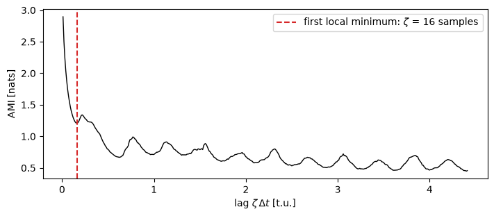

```python
max_lag = max(2, int(l63.t_CR / l63.dt))
ami = ntsa_tools.average_mutual_information(x, max_lag)
zeta = ntsa_tools.optimal_lag(x, max_lag=max_lag)
print(f"zeta = {zeta} samples = {zeta * dt:.3f} t.u. = {zeta * dt / l63.t_lyap:.2f} t_lyap")

fig, ax = plt.subplots(figsize=(7, 3), layout='constrained')
lags = np.arange(1, max_lag + 1) * dt
ax.plot(lags, ami, color='k', lw=1)
ax.axvline(zeta * dt, color='tab:red', ls='--', label=rf'first local minimum: $\zeta$ = {zeta} samples')
ax.set(xlabel=r'lag $\zeta\,\Delta t$ [t.u.]', ylabel='AMI [nats]')
ax.legend();
```

```
FNN embedding dimension d = 3;  fractions = [0.9876 0.0756 0.        nan    nan    nan    nan    nan    nan    nan]
```

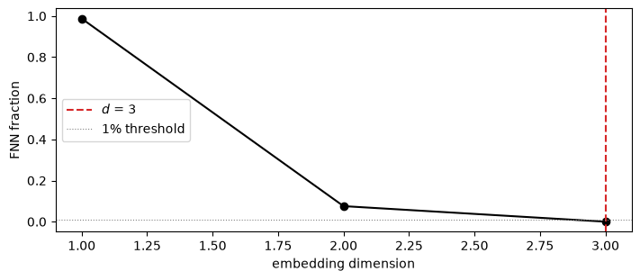

```python
d, fractions = ntsa_tools.false_nearest_neighbours(x, zeta)
print(f"FNN embedding dimension d = {d};  fractions = {np.array2string(fractions, precision=4)}")

fig, ax = plt.subplots(figsize=(7, 3), layout='constrained')
dims = np.arange(1, len(fractions) + 1)
ax.plot(dims, fractions, 'o-', color='k')
ax.axvline(d, color='tab:red', ls='--', label=f'$d$ = {d}')
ax.axhline(0.01, color='grey', lw=0.8, ls=':', label='1% threshold')
ax.set(xlabel='embedding dimension', ylabel='FNN fraction')
ax.legend();
```

The payoff: from the **single scalar** $x(t)$, the 3-D delay portrait reconstructs a diffeomorphic copy of the Lorenz butterfly — compare it with the true $(x, y, z)$ attractor from `psi`. Wing shapes and the fold are all recovered; only a smooth change of coordinates separates the two pictures.

```
embedded trajectory: (6512, 3) = (Nt - (dim-1)*lag, dim)
```

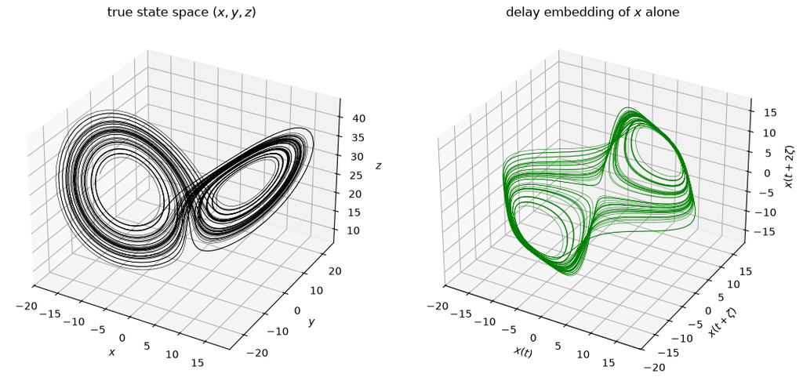

```python
Y = ntsa_tools.delay_embed(x, dim=3, lag=zeta)
print(f"embedded trajectory: {Y.shape} = (Nt - (dim-1)*lag, dim)")

fig = plt.figure(figsize=(11, 5), layout='constrained')
ax1 = fig.add_subplot(1, 2, 1, projection='3d')
ax1.plot(psi[:, 0], psi[:, 1], psi[:, 2], lw=0.4, color='k')
ax1.set(xlabel='$x$', ylabel='$y$', zlabel='$z$', title='true state space $(x, y, z)$')
ax2 = fig.add_subplot(1, 2, 2, projection='3d')
ax2.plot(Y[:, 0], Y[:, 1], Y[:, 2], lw=0.4, color='green')
ax2.set(xlabel='$x(t)$', ylabel=r'$x(t+\zeta)$', zlabel=r'$x(t+2\zeta)$',
        title='delay embedding of $x$ alone');
```

## 5. First-return map and recurrence plot

**First-return map.** Lorenz (1963) noticed that plotting each local maximum of $z$ against the next one collapses the chaotic flow onto a nearly one-dimensional curve — the famous **cusp map**. That unimodal, tent-like structure is the smoking gun of low-dimensional deterministic chaos: the maxima do not scatter randomly (stochasticity) and do not collapse onto $k$ isolated points (a period-$k$ limit cycle) — they fill a *continuum* lying on a deterministic curve. `first_return_map` extracts the successive maxima, and `count_peak_clusters` counts distinct peak levels; when it detects a continuum band it returns the number of peaks itself as a sentinel, so a chaotic signal is never mistaken for a small-period cycle.

```
86 local maxima;  count_peak_clusters -> 86 (= n_peaks sentinel: a continuum band, not a period-k cycle)
```

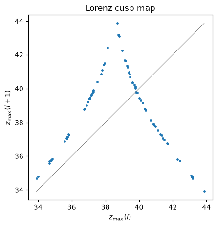

```python
z = y[:, 2]
zm_i, zm_ip1, pk_idx = ntsa_tools.first_return_map(z)
k = ntsa_tools.count_peak_clusters(z[pk_idx], x_range=np.ptp(z))
print(f"{len(pk_idx)} local maxima;  count_peak_clusters -> {k} "
      f"(= n_peaks sentinel: a continuum band, not a period-k cycle)")

fig, ax = plt.subplots(figsize=(4.5, 4.5), layout='constrained')
lo, hi = zm_i.min(), zm_i.max()
ax.plot([lo, hi], [lo, hi], color='grey', lw=0.8)
ax.scatter(zm_i, zm_ip1, s=6, color='tab:blue')
ax.set(xlabel=r'$z_{\max}(i)$', ylabel=r'$z_{\max}(i+1)$', title='Lorenz cusp map')
ax.set_aspect('equal');
```

**Recurrence plot** (Eckmann, Kamphorst & Ruelle 1987; review: Marwan et al. 2007). Using the embedded trajectory, mark all pairs of times whose states are close:

$$R_{ij} = \Theta\big(\varepsilon - \lVert \mathbf{Y}_i - \mathbf{Y}_j \rVert\big),$$

here with $\varepsilon$ = 10% of the maximum pairwise distance (`recurrence_matrix`). The *texture* of the black dots reads like a fingerprint of the regime:

- **periodic** — unbroken diagonal lines with *evenly spaced* offsets (the orbit returns exactly every period);
- **quasiperiodic** — diagonals with *unevenly spaced* offsets (two incommensurate periods never quite line up);
- **chaotic** — *short, broken* diagonals: trajectories shadow each other for a while (the determinism) and then diverge (the positive Lyapunov exponent). Isolated points would indicate noise.

```
recurrence matrix: (1468, 1468), density = 0.055
```

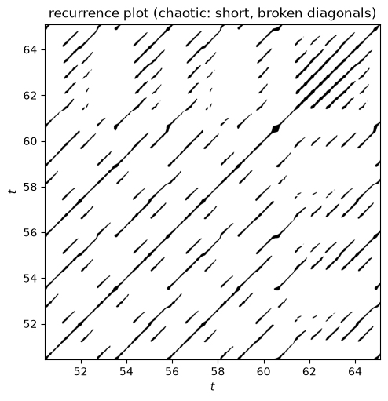

```python
n_win = 1500                       # trailing window of 15 t.u. (~3.4 recurrence times)
Y_win = ntsa_tools.delay_embed(x[-n_win:], dim=d, lag=zeta)
R = ntsa_tools.recurrence_matrix(Y_win, eps_frac=0.10)
t_w = t[-n_win:][:R.shape[0]]
print(f"recurrence matrix: {R.shape}, density = {R.mean():.3f}")

fig, ax = plt.subplots(figsize=(5, 5), layout='constrained')
ax.imshow(R, cmap='binary', origin='lower', extent=[t_w[0], t_w[-1], t_w[0], t_w[-1]])
ax.set(xlabel='$t$', ylabel='$t$', title='recurrence plot (chaotic: short, broken diagonals)');
```

## 6. Lyapunov exponents

### 6a. Leading exponent from perturbation growth

The leading Lyapunov exponent measures the mean exponential divergence of nearby trajectories,

$$\lambda_1 = \lim_{t\to\infty} \frac{1}{t} \ln \frac{\lVert \delta(t) \rVert}{\lVert \delta(0) \rVert},$$

and $\lambda_1 > 0$ *is* the operational definition of chaos. `leading_lyapunov` implements the most model-agnostic estimator: integrate one reference trajectory and `n_pert` copies perturbed by $\varepsilon \sim 10^{-6}$ (serially, $m = 1$ each — it works for **any** model, including discrete maps like the ESN), and fit a line to the mean log-separation. The fit window is chosen automatically — from the separation minimum up to 70% of the rise towards the saturation level (once the separation reaches the attractor size, growth must stop) — and fits with $R^2 < 0.5$ are **rejected** (`lam1 = nan`), which is what happens for non-chaotic signals where there is no exponential growth to fit. Reference value: $\lambda_1 \approx 0.906$, i.e. $t_\mathrm{lyap} = 1/0.9056 \approx 1.10$ time units.

```
lambda_1 = 0.9469 +/- 0.0896   (R^2 = 0.889; reference 0.906)
```

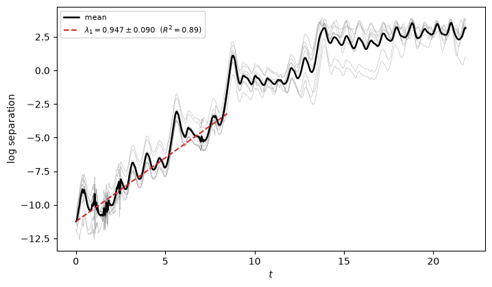

```python
lam1, lam1_std, res = lyap.leading_lyapunov(ntsa_tools.respawn(l63), n_pert=8)
print(f"lambda_1 = {lam1:.4f} +/- {lam1_std:.4f}   (R^2 = {res['r2']:.3f}; reference 0.906)")
assert 0.6 < lam1 < 1.2, f"lam1 = {lam1} outside (0.6, 1.2)"
chz.plot_lyapunov_fit(res);
```

Grey curves are the individual perturbations, black their mean, and the red dashed line the automatic fit window — note how the curve saturates at $\ln(\text{attractor size})$, which is exactly why the fit must stop before saturation.

### 6b. The full spectrum: Benettin's QR algorithm

A $d$-dimensional system has $d$ Lyapunov exponents, describing the growth rates of infinitesimal volumes: a $k$-dimensional parallelepiped of perturbations grows like $\exp\!\big(t \sum_{j\le k} \lambda_j\big)$. They are computed from the **variational (tangent-linear) dynamics** $\dot{\mathbf{U}} = J(\mathbf{u}(t))\,\mathbf{U}$ propagated alongside the state. Numerically all tangent columns collapse onto the leading direction, so Benettin et al. (1980) periodically re-orthonormalize with a QR decomposition and accumulate the logs of the diagonal of $R$:

$$\lambda_j = \frac{1}{T} \sum_{\mathrm{QR\ steps}} \ln \lvert R_{jj} \rvert .$$

`lyapunov_spectrum` integrates state + tangent matrix with a joint fixed-step RK4 (sharing the RK stages), QR every `N_gs = 4` steps, `dt = min(model.dt, 0.01)`. It needs the Jacobian: `get_jacobian` returns the **analytic** one for Lorenz-63/96 and falls back to central finite differences (`fd_jacobian`) for any other model. For Lorenz-63,

$$J(\mathbf{u}) = \begin{pmatrix} -\sigma & \sigma & 0 \\ \rho - z & -1 & -x \\ y & x & -\beta \end{pmatrix},$$

and since the RHS is quadratic, central differences should agree to near machine precision:

```python
f = lyap.get_rhs(l63)               # f(u) -> du/dt from model.time_derivative
jac = lyap.get_jacobian(l63)        # analytic for Lorenz63/96, FD fallback otherwise
u_test = np.array([-6.0, 8.0, 27.0])
J_an, J_fd = jac(u_test), lyap.fd_jacobian(f, u_test)
rel_err = np.abs(J_fd - J_an).max() / np.abs(J_an).max()
print("analytic J(u_test) =\n", J_an)
print(f"max relative error, finite differences vs analytic: {rel_err:.2e}")
assert rel_err < 1e-6, rel_err
```

```
analytic J(u_test) =
 [[-10.          10.           0.        ]
 [  1.          -1.           6.        ]
 [  8.          -6.          -2.66666667]]
max relative error, finite differences vs analytic: 1.56e-10
```

```python
exps = lyap.lyapunov_spectrum(l63)   # floor 200 t_lyap, auto-extends until converged  (~5 s)
print(f"\nBenettin spectrum: {np.array2string(exps, precision=4)}   reference: (0.906, 0, -14.57)")
assert abs(exps[0] - 0.906) < 0.1, f"lambda1 = {exps[0]}"
assert abs(exps[1]) < 2e-3, f"lambda2 = {exps[1]}"
```

```
  GS 8724/436205  lam1=0.9173
```

```
  GS 17448/436205  lam1=0.8959
  GS 26172/436205  lam1=0.9028
  GS 34896/436205  lam1=0.9062
  GS 43620/436205  lam1=0.9025
Lyapunov spectrum (T=501.4, converged): [ 9.0572e-01  7.1831e-04 -1.4573e+01]

Benettin spectrum: [ 9.0572e-01  7.1831e-04 -1.4573e+01]   reference: (0.906, 0, -14.57)
```

**How long is long enough?** Finite-time Lyapunov estimates converge slowly — the neutral (along-flow) exponent, exactly 0 for any attractor of a flow, decays only as $O(1/T)$ — and a fixed horizon cannot know when it is done. `lyapunov_spectrum` therefore treats `t_run` (default $200\,t_\mathrm{ref}$) as a *floor* and keeps integrating (up to `t_max = 20*t_run`) until every running exponent passes a **halving test** at two consecutive checks,

$$\lvert \lambda_j(T) - \lambda_j(T/2) \rvert < \max(\mathrm{atol},\ \mathrm{rtol}\,\lvert \lambda_j(T) \rvert), \qquad \mathrm{atol} = 2\times10^{-3},\ \mathrm{rtol} = 5\%,$$

warning if the cap is hit unconverged; `full_output=True` returns the running-estimate history. Two guards matter especially for **limit cycles**, where finite-time $\lambda_1$ is easily overestimated: (i) the warmup (`_settled_state`) doubles the discarded transient until a probe run shows no residual amplitude drift — a still-settling state reads as tangent growth, and near a Hopf point no fixed transient multiple is safe — and (ii) the halving test keeps extending until the neutral exponent lands within $\sim$atol of zero (VdP: $+0.005$ at the auto-chosen $T \approx 31$, vs $+0.018$ at the old fixed $T = 8$).

A free consistency check: the sum of all exponents equals the time-averaged divergence of the flow, $\sum_j \lambda_j = \langle \nabla \cdot \mathbf{f} \rangle$. For Lorenz-63 the divergence is *constant*, $\nabla \cdot \mathbf{f} = -(\sigma + 1 + \beta) = -13.667$ — the **trace identity** the spectrum must reproduce:

```
sum(lambda) = -13.6666    vs    -(sigma+1+beta) = -13.6667
```

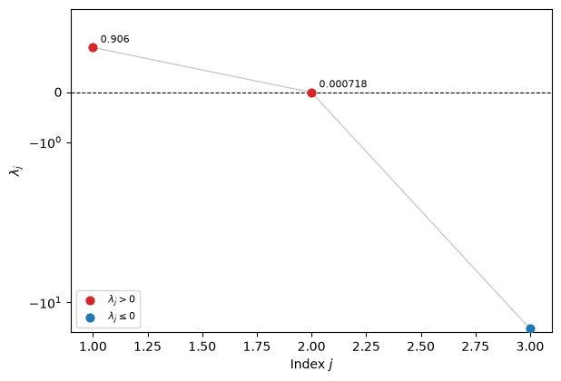

```python
trace_j = -(l63.sigma + 1.0 + l63.beta)
print(f"sum(lambda) = {exps.sum():.4f}    vs    -(sigma+1+beta) = {trace_j:.4f}")
assert abs(exps.sum() - trace_j) < 0.5, f"trace identity violated: {exps.sum()} vs {trace_j}"
chz.plot_lyapunov_spectrum(exps);
```

### 6c. Outlook: covariant Lyapunov vectors

The Gram–Schmidt vectors of the Benettin pass are orthogonal by construction and *not* covariant with the dynamics. The **covariant Lyapunov vectors** of Ginelli et al. (2007) — obtained by storing the $Q, R$ factors of the forward pass and back-iterating the upper-triangular expansion coefficients — give the true intrinsic stable/unstable directions (useful e.g. for projected data assimilation). The module documents this as a stub:

```python
try:
    lyap.covariant_lyapunov_vectors()
except NotImplementedError as err:
    print(f"NotImplementedError: {err}")
```

```
NotImplementedError: CLVs: Ginelli et al. 2007 — store Q,R in forward Benettin pass, backward-iterate upper-triangular coeffs. Not implemented yet.
```

### 6d. Kaplan–Yorke dimension

The spectrum also yields a fractal-dimension estimate. With $j$ the largest index such that $\sum_{i \le j} \lambda_i \ge 0$, the **Kaplan–Yorke (Lyapunov) dimension** is

$$D_{KY} = j + \frac{\sum_{i \le j} \lambda_i}{\lvert \lambda_{j+1} \rvert}.$$

For Lorenz-63, $j = 2$ (since $\lambda_2 = 0$) and $D_{KY} = 2 + \lambda_1 / \lvert \lambda_3 \rvert \approx 2.06$ — the attractor is "slightly more than a surface".

```python
D_KY = lyap.kaplan_yorke(exps)   # module implementation (tolerance-guarded neutral jitter)
print(f"D_KY(Lorenz-63) = {D_KY:.3f}   (expect ~2.06)")
assert 1.9 < D_KY < 2.2, D_KY
```

```
D_KY(Lorenz-63) = 2.062   (expect ~2.06)
```

### 6e. Torus dimension: neutral exponents, correlation dimension, Poincaré section

Along a Ruelle–Takens–Newhouse route (periodic → 2-torus → breakdown → chaos) the regime is pinned down by three independent witnesses: the number of **neutral** exponents in the converged spectrum ($k$ zeros ⇔ attractor $T^k$; a positive one ⇔ chaos), the Grassberger–Procaccia **correlation dimension** (`correlation_dimension`, $D_2 \approx k$ on a $k$-torus, fractal for chaos), and the plane-crossing **Poincaré section** (`poincare_section`: a section of $T^k$ has $D_2 \approx k-1$ — dots → loop → band; chaos → fractal scatter). On Lorenz-96 ($N_x = 10$) these resolve the breakdown region: $F = 4.3$ is a clean 2-torus (two zeros, $D_2 \approx 1.8$, loop section) while $F = 4.6$ is a chaotic *wrinkled torus* ($\lambda_1 = +0.039$ converged, $D_2 \approx 2.15$, section still loop-like) — the geometry stays toroidal after the dynamics turn chaotic, so the spectrum, not the eye, makes the call.

```
D2: L63 1.66 (fractal ~2.06) | two-tone torus 1.98 (~2) | its section 1.02 (~1)
```

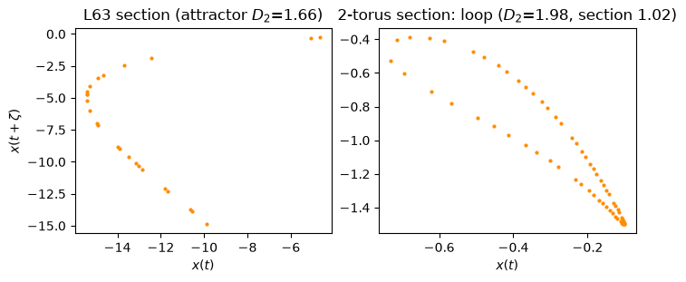

```python
# correlation dimension: L63 attractor (fractal ~2.06) vs a synthetic 2-torus signal
D2_l63, _ = ntsa_tools.correlation_dimension(psi)
tt = np.arange(0, 400, 0.05)
x2 = np.sin(tt) + 0.5 * np.sin(np.sqrt(2) * tt)          # two incommensurate tones -> T^2
zeta2 = ntsa_tools.optimal_lag(x2)
D2_torus, _ = ntsa_tools.correlation_dimension(ntsa_tools.delay_embed(x2, 3, zeta2))

# plane-crossing Poincare sections: chaos -> fractal scatter; 2-torus -> closed loop
P_l63 = ntsa_tools.poincare_section(x, zeta)
P_torus = ntsa_tools.poincare_section(x2, zeta2)
D2_sec, _ = ntsa_tools.correlation_dimension(P_torus)

fig, axs = plt.subplots(1, 2, figsize=(7, 3), layout='constrained')
axs[0].scatter(P_l63[:, 0], P_l63[:, 1], s=4, color='darkorange')
axs[0].set(title=f'L63 section (attractor $D_2$={D2_l63:.2f})', xlabel='$x(t)$', ylabel=r'$x(t+\zeta)$')
axs[1].scatter(P_torus[:, 0], P_torus[:, 1], s=4, color='darkorange')
axs[1].set(title=f'2-torus section: loop ($D_2$={D2_torus:.2f}, section {D2_sec:.2f})', xlabel='$x(t)$')
print(f"D2: L63 {D2_l63:.2f} (fractal ~2.06) | two-tone torus {D2_torus:.2f} (~2) | its section {D2_sec:.2f} (~1)")
assert 1.6 < D2_torus < 2.4 and 0.6 < D2_sec < 1.4
```

## 7. Classical MDS attractor portraits

When the state dimension is large (Lorenz-96, POD coefficients of a flow, ...) we cannot plot the attractor directly. **Classical multidimensional scaling** (Torgerson 1952) finds the low-dimensional coordinates that best preserve all pairwise distances: square the Euclidean distance matrix $D$, double-centre it with $C = I - \tfrac{1}{T}\mathbf{1}\mathbf{1}^\top$ to recover the Gram matrix

$$A = -\tfrac{1}{2}\, C D^{(2)} C = V \Lambda V^\top,$$

and map each snapshot to $\gamma = V_{1:k} \sqrt{\Lambda_{1:k}}$ using the top eigenpairs. For Euclidean input this is equivalent to PCA on the centred coordinates, so the $\gamma_i$ are ordered by variance. `classical_mds` subsamples the trajectory to at most 2000 snapshots (the Gram matrix is $T \times T$) and returns both $\gamma$ and the snapshot indices, so you can colour the portrait by time.

```
gamma: (2000, 3), coordinate variances (descending): [135.51  76.83   9.1 ]
```

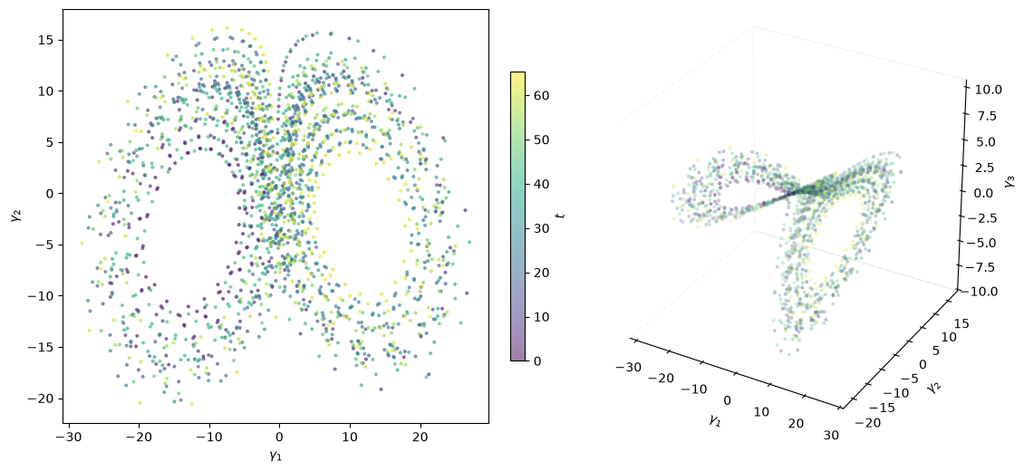

```python
gamma, idx = ntsa_tools.classical_mds(psi)       # (T, 3) coordinates + subsample indices
print(f"gamma: {gamma.shape}, coordinate variances (descending): {np.round(gamma.var(axis=0), 2)}")
chz.plot_mds(gamma, t[idx]);
```

## 8. Regime classification

`classify_regime(x, dt, lam1=None, ...)` distils the evidence above into a label, via a decision tree (Kantz & Schreiber ch. 1, 3, 5):

1. **fixed point** — the trailing fifth of the signal is flat (oscillation died out), or the full Lyapunov spectrum is entirely negative (decisive when integrator noise keeps the tail wiggling at a stable focus — e.g. Lorenz-63 at $\rho = 10$: $\lambda = [-0.6, -0.6, -12.5]$);
2. **limit cycle, period-$k$** — the local maxima form $k \le k_\mathrm{max}$ *tight* clusters (`count_peak_clusters`). Checked **before** the Lyapunov step: $k$ tight maxima levels over a long record are incompatible with chaos, whereas a perturbation-growth $\lambda_1$ can read large and positive on a stable orbit through non-normal transient amplification (thermoacoustic limit cycles otherwise read $\lambda_1 \sim 200$);
3. **chaotic** — the leading Lyapunov exponent is positive *beyond a trust tolerance* `lam_tol = max(3*lam1_std, 10/T)` (a finite-time estimate on a horizon $T$ cannot resolve rates below ~$10/T$);
4. otherwise: with a full spectrum, $\ge 2$ *neutral* exponents ($|\lambda| <$ `neutral_tol`) $\to$ **quasiperiodic** — a 2-torus has two zero exponents, a locked periodic orbit exactly one, which is more robust than the PSD rational-ratio test (`limit_denominator(10)` rationals are dense: L96 at $F = 4.4$ has $f_2/f_1 = 0.552 \approx 5/9$ yet $\lambda = [0.001, 0.000, -0.003]$ is a torus). Else PSD peak analysis: after removing harmonics of the dominant peak $f_1$, is there a second incommensurate peak $f_2$? A **rational** ratio $f_2/f_1$ (matched to a fraction with denominator $\le 10$) means **frequency-locked**; an irrational ratio means **quasiperiodic**; no $f_2$ at all means a plain **limit cycle**.

It returns `(label, evidence)` — the evidence dict is what you show a reviewer. We test the tree on three signals: chaotic Lorenz-63 ($\rho = 28$, with the $\lambda_1$ measured in Section 6), the $\rho = 350$ periodic window of Lorenz-63 (a fast period-1 orbit, hence the finer `dt = 0.005`), and a synthetic two-tone signal $\sin(t) + \sin(\sqrt{2}\, t)$ whose frequency ratio is irrational by construction.

```python
def show_evidence(ev):
    for key, val in ev.items():
        if isinstance(val, np.ndarray):
            val = (f"array of {len(val)} peaks: " + np.array2string(val[:5], precision=3)
                   + (' ...' if len(val) > 5 else ''))
        elif isinstance(val, float):
            val = round(val, 4)
        print(f"  {key:>16}: {val}")

label_ch, ev_ch = ntsa_tools.classify_regime(x, dt, lam1=lam1, lam1_std=lam1_std,
                                             t_total=t[-1] - t[0])
print(f"Lorenz-63, rho=28   ->   {label_ch}")
show_evidence(ev_ch)
assert label_ch == 'chaotic', label_ch
```

```
Lorenz-63, rho=28   ->   chaotic
           lambda1: 0.9469
       lambda1_std: 0.0896
           lam_tol: 0.2687
        n_clusters: 61
    psd_peak_freqs: array of 54 peaks: [0.031 0.076 0.153 0.199 0.29 ] ...
                f1: 0.0306
                f2: 0.5656
    rational_match: 37/2
         tail_flat: False
         n_neutral: None
             label: chaotic
```

```python
l63_350 = ntsa_tools.respawn(l63, rho=350., dt=0.005)
t3, y3, _ = ntsa_tools.run_long(l63_350, t_run=10.)
label_lc, ev_lc = ntsa_tools.classify_regime(y3[:, 0], float(t3[1] - t3[0]))
print(f"Lorenz-63, rho=350   ->   {label_lc}")
show_evidence(ev_lc)
assert label_lc == 'limit_cycle_period_1', label_lc
```

```
Lorenz-63, rho=350   ->   limit_cycle_period_1
           lambda1: None
       lambda1_std: 0.0
           lam_tol: None
        n_clusters: 1
    psd_peak_freqs: array of 2 peaks: [2.603 7.708]
                f1: 2.6026
                f2: None
    rational_match: None
         tail_flat: False
         n_neutral: None
             label: limit_cycle_period_1
```

```python
tt = np.arange(0, 500, 0.05)
xq = np.sin(tt) + np.sin(np.sqrt(2.0) * tt)      # two incommensurate tones
label_qp, ev_qp = ntsa_tools.classify_regime(xq, dt=0.05)
print(f"two-tone sin(t) + sin(sqrt(2) t)   ->   {label_qp}")
show_evidence(ev_qp)
assert label_qp == 'quasiperiodic', label_qp
```

```
two-tone sin(t) + sin(sqrt(2) t)   ->   quasiperiodic
           lambda1: None
       lambda1_std: 0.0
           lam_tol: 0.02
        n_clusters: 113
    psd_peak_freqs: array of 2 peaks: [0.16  0.226]
                f1: 0.16
                f2: 0.226
    rational_match: None
         tail_flat: False
         n_neutral: None
             label: quasiperiodic
```

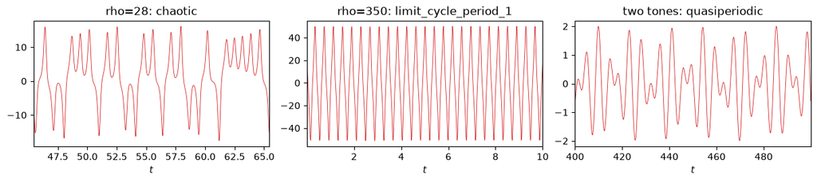

```python
fig, axs = plt.subplots(1, 3, figsize=(12, 2.6), layout='constrained')
for ax, (tv, sig, ttl) in zip(axs, [(t, x, f'rho=28: {label_ch}'),
                                    (t3, y3[:, 0], f'rho=350: {label_lc}'),
                                    (tt, xq, f'two tones: {label_qp}')]):
    n = min(len(tv), 2000)
    ax.plot(tv[-n:], sig[-n:], lw=0.6, color='tab:red')
    ax.set(title=ttl, xlabel='$t$')
    ax.margins(x=0)
```

## 9. The one-call characterization: `characterize()`

We run it on the chaotic/periodic Lorenz-63 pair (the busiest cell of the notebook: two full pipelines, spectra included).

```python
cases = [ntsa_tools.respawn(l63),                       # rho = 28 : chaotic
         ntsa_tools.respawn(l63, rho=350., dt=0.005)]   # rho = 350: period-1 limit cycle
results = chz.characterize(cases, pdf_name='figs/tutorial_l63_pair.pdf')

for r in results:
    print(f"{r['label']:<45} -> {r['regime']:<22} zeta={r['zeta']}, d={r['dim']}")
assert results[0]['regime'] == 'chaotic', results[0]['regime']
assert results[1]['regime'] == 'limit_cycle_period_1', results[1]['regime']
```

```
-- characterizing: Lorenz63 (rho=28, sigma=10, beta=2.667)
```

```
  GS 8724/436205  lam1=0.9173
  GS 17448/436205  lam1=0.8959
  GS 26172/436205  lam1=0.9028
  GS 34896/436205  lam1=0.9062
  GS 43620/436205  lam1=0.9025
Lyapunov spectrum (T=501.4, converged): [ 9.0572e-01  7.1831e-04 -1.4573e+01]
```

```
-- characterizing: Lorenz63 (rho=350, sigma=10, beta=2.667)
```

```
  GS 4416/883392  lam1=0.0100
  GS 8832/883392  lam1=0.0272
  GS 13248/883392  lam1=0.0008
  GS 17664/883392  lam1=0.0021
  GS 22080/883392  lam1=0.0108
  GS 26496/883392  lam1=0.0007
  GS 30912/883392  lam1=0.0010
  GS 35328/883392  lam1=0.0067
  GS 39744/883392  lam1=0.0007
  GS 44160/883392  lam1=0.0005
  GS 48576/883392  lam1=0.0049
  GS 52992/883392  lam1=0.0007
```

```
  GS 57408/883392  lam1=0.0003
  GS 61824/883392  lam1=0.0038
  GS 66240/883392  lam1=0.0007
  GS 70656/883392  lam1=0.0001
  GS 75072/883392  lam1=0.0031
  GS 79488/883392  lam1=0.0007
Lyapunov spectrum (T=397.44, converged): [ 6.8799e-04 -7.3134e-01 -1.2936e+01]
```

```
Saved figures --> figs/tutorial_l63_pair.pdf
Lorenz63 (rho=28, sigma=10, beta=2.667)       -> chaotic                zeta=16, d=3
Lorenz63 (rho=350, sigma=10, beta=2.667)      -> limit_cycle_period_1   zeta=20, d=2
```

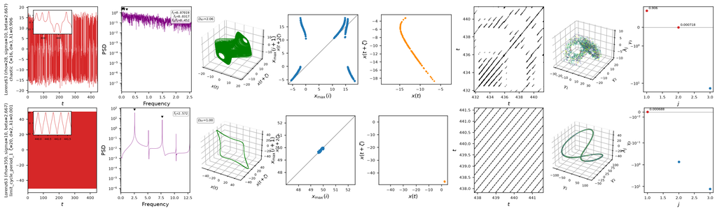

```python
Image('figs/tutorial_l63_pair.png')    # first page of figs/tutorial_l63_pair.pdf
```

How to read a row, left to right (this is the layout of the paper-supplement figure):

1. **time series** (red) with a zoom inset spanning ~5 dominant periods — the row title carries the regime call, $\zeta$, $d$ and $\lambda_1$;
2. **PSD** (purple, semilogy) — broadband floor for chaos vs a clean line spectrum for the limit cycle. The black triangles are the peaks found by `classify_regime`, and the **text box lists $f_1$, $f_2$ and their ratio** — precisely the numbers that drive the LC / frequency-locked / QP / chaotic call, so the classification can be audited by eye;
3. **3-D delay portrait** (green) — butterfly vs closed loop;
4. **first-return map** (blue) — continuum on the cusp curve vs a single point on the identity line;
5. **recurrence plot** — broken short diagonals vs evenly spaced unbroken diagonals.

## 10. A higher-dimensional test: Lorenz-96

The Lorenz-96 lattice,

$$\dot{x}_i = (x_{i+1} - x_{i-2})\, x_{i-1} - x_i + F, \qquad i = 0, \dots, N_x - 1 \ \ (\text{cyclic}),$$

is the standard data-assimilation testbed: advection-like quadratic coupling, linear damping, constant forcing $F$. With $N_x = 10$ and $F = 8$ it is chaotic with **several** positive Lyapunov exponents ($\lambda_1 \approx 1.2$, three positive) — genuinely higher-dimensional chaos, unlike Lorenz-63. All tools above apply unchanged.

```
t: (5069,), y: (5069, 3), psi: (5069, 10);  observed sites: [0, 5, 9]
```

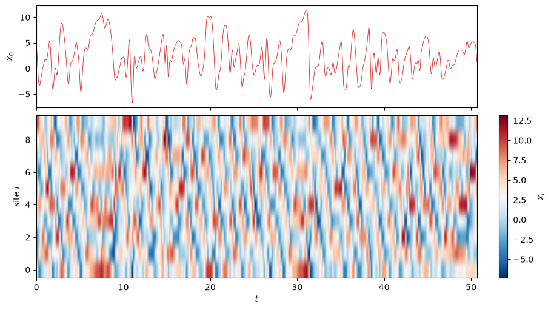

```python
l96 = Lorenz96(Nx=10, F=8., dt=0.01)
t96, y96, psi96 = ntsa_tools.run_long(ntsa_tools.respawn(l96), t_run=60 * l96.t_lyap)
dt96 = float(t96[1] - t96[0])
x96 = y96[:, 0]
print(f"t: {t96.shape}, y: {y96.shape}, psi: {psi96.shape};  observed sites: {l96.observed_idx}")

fig, (ax0, ax1) = plt.subplots(2, 1, figsize=(9, 5), sharex=True, layout='constrained',
                               gridspec_kw=dict(height_ratios=[1, 1.6]))
ax0.plot(t96, x96, lw=0.6, color='tab:red')
ax0.set_ylabel(l96.obs_labels[0])
ax0.margins(x=0)
im = ax1.imshow(psi96.T, aspect='auto', origin='lower', cmap='RdBu_r',
                extent=[t96[0], t96[-1], -0.5, l96.Nx - 0.5])
ax1.set(xlabel='$t$', ylabel='site $i$')
fig.colorbar(im, ax=ax1, label='$x_i$');
```

```python
zeta96 = ntsa_tools.optimal_lag(x96, max_lag=max(2, int(l96.t_CR / l96.dt)))
d96, fr96 = ntsa_tools.false_nearest_neighbours(x96, zeta96)
print(f"zeta = {zeta96} samples ({zeta96 * dt96:.2f} t.u.);  FNN dimension d = {d96}")
print(f"FNN fractions: {np.array2string(fr96, precision=3)}")
```

```
zeta = 26 samples (0.26 t.u.);  FNN dimension d = 4
FNN fractions: [0.996 0.521 0.069 0.004   nan   nan   nan   nan   nan   nan]
```

The full Benettin spectrum with `n_exp = 10` (all of them — the analytic cyclic-banded Jacobian makes this cheap). Two things to verify: $\lambda_1 \approx 1.2$ with three positive exponents, and the trace identity — for Lorenz-96 every diagonal Jacobian entry is $-1$, so $\sum_j \lambda_j = -N_x = -10$ exactly.

```
  GS 6756/337837  lam1=1.3522
```

```
  GS 13512/337837  lam1=1.2854
```

```
  GS 20268/337837  lam1=1.2232
```

```
  GS 27024/337837  lam1=1.1832
```

```
  GS 33780/337837  lam1=1.2034
```

```
  GS 40536/337837  lam1=1.2085
```

```
  GS 47292/337837  lam1=1.2012
```

```
  GS 54048/337837  lam1=1.1979
```

```
  GS 60804/337837  lam1=1.2098
```

```
  GS 67560/337837  lam1=1.2008
```

```
  GS 74316/337837  lam1=1.2158
```

```
  GS 81072/337837  lam1=1.2004
```

```
  GS 87828/337837  lam1=1.1910
```

```
  GS 94584/337837  lam1=1.1963
```

```
  GS 101340/337837  lam1=1.2018
```

```
  GS 108096/337837  lam1=1.2009
```

```
  GS 114852/337837  lam1=1.2064
```

```
  GS 121608/337837  lam1=1.2024
```

```
  GS 128364/337837  lam1=1.2008
```

```
  GS 135120/337837  lam1=1.2005
```

```
  GS 141876/337837  lam1=1.1966
```

```
  GS 148632/337837  lam1=1.1875
```

```
  GS 155388/337837  lam1=1.1864
```

```
  GS 162144/337837  lam1=1.1891
```

```
  GS 168900/337837  lam1=1.1891
```

```
  GS 175656/337837  lam1=1.1867
```

```
  GS 182412/337837  lam1=1.1900
```

```
  GS 189168/337837  lam1=1.1839
```

```
  GS 195924/337837  lam1=1.1884
```

```
  GS 202680/337837  lam1=1.1913
```

```
  GS 209436/337837  lam1=1.1845
```

```
  GS 216192/337837  lam1=1.1855
```

```
  GS 222948/337837  lam1=1.1791
```

```
  GS 229704/337837  lam1=1.1777
```

```
  GS 236460/337837  lam1=1.1806
```

```
  GS 243216/337837  lam1=1.1797
```

```
  GS 249972/337837  lam1=1.1809
```

```
  GS 256728/337837  lam1=1.1841
```

```
  GS 263484/337837  lam1=1.1888
```

```
  GS 270240/337837  lam1=1.1901
```

```
  GS 276996/337837  lam1=1.1919
```

```
  GS 283752/337837  lam1=1.1869
```

```
  GS 290508/337837  lam1=1.1819
```

```
  GS 297264/337837  lam1=1.1846
```

```
  GS 304020/337837  lam1=1.1848
```

```
  GS 310776/337837  lam1=1.1861
```

```
  GS 317532/337837  lam1=1.1843
```

```
  GS 324288/337837  lam1=1.1833
```

```
Lyapunov spectrum (T=3274.72, converged): [ 1.1809e+00  6.9042e-01  8.4933e-02 -4.5108e-03 -4.5208e-01 -8.7725e-01
 -1.3333e+00 -1.9145e+00 -2.7762e+00 -4.5984e+00]

lambda_1 = 1.181 (expect ~1.2);  3 positive exponents (expect 3)
sum(lambda) = -10.000  vs  -Nx = -10
Kaplan-Yorke dimension = 6.47  (of Nphi = 10)
```

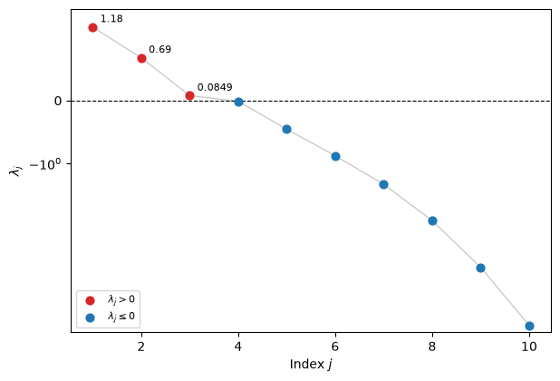

```python
exps96 = lyap.lyapunov_spectrum(l96, n_exp=10)     # ~40 s (auto-extends until converged)
n_pos = int((exps96 > 0.05).sum())
print(f"\nlambda_1 = {exps96[0]:.3f} (expect ~1.2);  {n_pos} positive exponents (expect 3)")
print(f"sum(lambda) = {exps96.sum():.3f}  vs  -Nx = {-l96.Nx}")
assert abs(exps96[0] - 1.2) < 0.4, exps96[0]
assert 2 <= n_pos <= 4, n_pos
assert abs(exps96.sum() + l96.Nx) < 0.5, exps96.sum()
D_KY96 = lyap.kaplan_yorke(exps96)
print(f"Kaplan-Yorke dimension = {D_KY96:.2f}  (of Nphi = {l96.Nphi})")
chz.plot_lyapunov_spectrum(exps96);
```

```
-- characterizing: Lorenz96 (F=8)
```

```
Saved figures --> figs/tutorial_l96.pdf
Lorenz96 (F=8) -> chaotic  (zeta=39, d=5, lambda1=1.018)
```

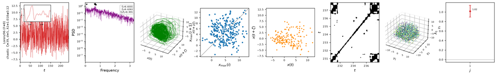

```python
res96 = chz.characterize(ntsa_tools.respawn(l96), spectrum=False,   # spectrum computed above
                         pdf_name='figs/tutorial_l96.pdf')
r = res96[0]
print(f"{r['label']} -> {r['regime']}  (zeta={r['zeta']}, d={r['dim']}, lambda1={r['lambda1']:.3f})")
assert r['regime'] == 'chaotic', r['regime']
Image('figs/tutorial_l96.png')
```

### A coarse bifurcation diagram in $F$

`bifurcation_sweep` is the module's generic route-to-chaos tool: for each parameter value it integrates past a transient and collects the local extrema of every observable. By default the whole sweep runs as **one ensemble forecast** — the swept parameter is augmented into the state (`init_ensemble(est_alpha=[param])`), so member $k$ integrates at `values[k]` from a shared initial state and the parameter values run in parallel. Plotted against the parameter, a **single** point per column means a period-1 orbit, $k$ points a period-$k$ orbit, and a **filled band** a chaotic (or quasiperiodic) attractor. With `continuation=True` the sweep falls back to a serial loop where each run starts from the previous endpoint (plus a tiny perturbation), which keeps the sweep on the same attractor branch — the standard numeric continuation trick, useful across hysteresis, but inherently sequential.

We sweep $F \in [2, 18]$ coarsely (28 values, short samples — the whole sweep takes a few seconds). The sweep starts just past the Hopf bifurcation of the fixed point $x_i = F$: at $F \approx 2$–$4$ the lattice carries a **periodic travelling wave** — a few isolated peak levels per column — and by $F \gtrsim 5$–$6$ the columns fill out into the bands of **chaos**, widening as the forcing grows.

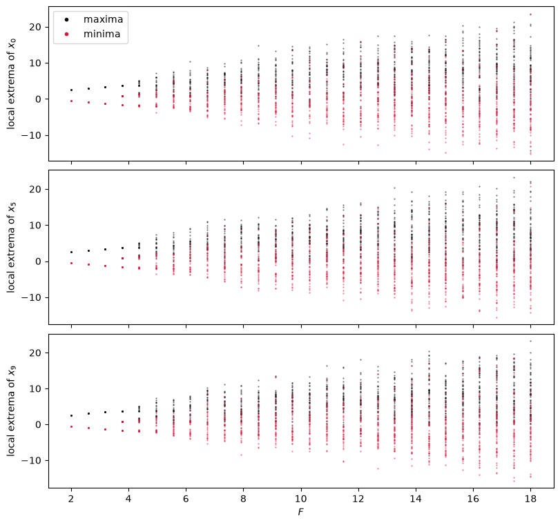

```python
F_values = np.linspace(2., 18., 28)
vals, peaks = ntsa_tools.bifurcation_sweep(l96, 'F', F_values,
                                           t_transient=10., t_sample=30.,
                                           extrema=('max', 'min'))
fig, axs = ntsa_tools.plot_bifurcation(vals, peaks, l96.alpha_labels['F'], l96.obs_labels)
```

A closing note on scope: the sweep is **completely generic** — it only needs `model.params`, `respawn` and the ensemble machinery every `dynamodels` model already carries, so the same two lines produce bifurcation diagrams for `VdP` (e.g. over $\beta$), `Rijke`, `Annular`, or any other model. For IVP models the ensemble mode uses a multiprocessing pool, so plain scripts (not notebooks) should guard the call with `if __name__ == '__main__':` under forkserver/spawn.

## 11. Summary

| Question about a signal | Tool | Key reference |
| --- | --- | --- |
| clean trajectory on the attractor | `respawn` + `run_long` | — |
| moments / PDF / PSD / ACF | `signal_stats` | Kantz & Schreiber (2004) ch. 2 |
| embedding delay $\zeta$ | `optimal_lag` (AMI minimum) | Fraser & Swinney (1986) |
| embedding dimension $d$ | `false_nearest_neighbours` | Kennel et al. (1992) |
| phase portrait from one scalar | `delay_embed` | Takens (1981) |
| periodicity of the orbit | `first_return_map` + `count_peak_clusters` | Lorenz (1963) |
| determinism / regime texture | `recurrence_matrix` | Eckmann et al. (1987); Marwan et al. (2007) |
| is it chaotic? ($\lambda_1$) | `leading_lyapunov` | Kantz & Schreiber (2004) ch. 5 |
| full spectrum, $D_{KY}$, trace check | `lyapunov_spectrum` (+ `get_rhs`/`get_jacobian`) | Benettin et al. (1980) |
| stable/unstable directions | `covariant_lyapunov_vectors` (stub) | Ginelli et al. (2007) |
| portrait of a high-dim state | `classical_mds` | Torgerson (1952) |
| the regime label + evidence | `classify_regime` | Kantz & Schreiber (2004) |
| route to chaos in a parameter | `bifurcation_sweep` + `plot_bifurcation` | — |
| **all of the above, one PDF** | `characterize` | this module |

```python
print('Measured in this notebook (all seeded, all assert-checked):')
print(f'  L63 rho=28  leading exponent (perturbation growth): {lam1:.3f} +/- {lam1_std:.3f}')
print(f'  L63 rho=28  Benettin spectrum: {np.array2string(exps, precision=3)}'
      f'   [sum = {exps.sum():.3f} vs -(sigma+1+beta) = {trace_j:.3f}]')
print(f'  L63 rho=28  Kaplan-Yorke dimension: {D_KY:.3f}')
print(f'  L96 F=8, Nx=10  spectrum: lambda1 = {exps96[0]:.3f}, {n_pos} positive, '
      f'sum = {exps96.sum():.2f} vs -Nx = {-l96.Nx}, D_KY = {D_KY96:.2f}')
print(f'  regimes: rho=28 -> {label_ch};  rho=350 -> {label_lc};  two-tone -> {label_qp}')
```

```
Measured in this notebook (all seeded, all assert-checked):
  L63 rho=28  leading exponent (perturbation growth): 0.947 +/- 0.090
  L63 rho=28  Benettin spectrum: [ 9.057e-01  7.183e-04 -1.457e+01]   [sum = -13.667 vs -(sigma+1+beta) = -13.667]
  L63 rho=28  Kaplan-Yorke dimension: 2.062
  L96 F=8, Nx=10  spectrum: lambda1 = 1.181, 3 positive, sum = -10.00 vs -Nx = -10, D_KY = 6.47
  regimes: rho=28 -> chaotic;  rho=350 -> limit_cycle_period_1;  two-tone -> quasiperiodic
```

### References

- Kantz, H. & Schreiber, T. (2004). *Nonlinear Time Series Analysis*, 2nd ed., Cambridge University Press.
- Lorenz, E. N. (1963). Deterministic nonperiodic flow. *J. Atmos. Sci.* 20, 130–141.
- Takens, F. (1981). Detecting strange attractors in turbulence. *Lecture Notes in Math.* 898.
- Fraser, A. M. & Swinney, H. L. (1986). Independent coordinates for strange attractors from mutual information. *Phys. Rev. A* 33, 1134.
- Kennel, M. B., Brown, R. & Abarbanel, H. D. I. (1992). Determining embedding dimension for phase-space reconstruction using a geometrical construction. *Phys. Rev. A* 45, 3403.
- Benettin, G., Galgani, L., Giorgilli, A. & Strelcyn, J.-M. (1980). Lyapunov characteristic exponents for smooth dynamical systems and for Hamiltonian systems. *Meccanica* 15, 9–30.
- Eckmann, J.-P., Kamphorst, S. O. & Ruelle, D. (1987). Recurrence plots of dynamical systems. *Europhys. Lett.* 4, 973.
- Marwan, N., Romano, M. C., Thiel, M. & Kurths, J. (2007). Recurrence plots for the analysis of complex systems. *Phys. Rep.* 438, 237–329.
- Torgerson, W. S. (1952). Multidimensional scaling: I. Theory and method. *Psychometrika* 17, 401–419.
- Ginelli, F., Poggi, P., Turchi, A., Chaté, H., Livi, R. & Politi, A. (2007). Characterizing dynamics with covariant Lyapunov vectors. *Phys. Rev. Lett.* 99, 130601.
- Lorenz, E. N. (1996). Predictability: a problem partly solved. *Proc. ECMWF Seminar on Predictability*, Vol. 1, 1–18.